# Stress State Prediction from Wearable Sensors: A Comparative Study of ARIMA and Random Forest on the WESAD Dataset

Author

Indupriya Uppaluri, Virginia Vaughan, Chawan Sreelekha (Advisor: Dr. Cohen)

Published

July 21, 2026

Slides: slides.html ( Go to `slides.qmd` to edit)

## Introduction

Stress detection in real-time, and more importantly biomarkers, have gained interest as both military and corporate facilities aim to improve the quality of worker health and performance. This has let to extensive research using commercial wearables that record signals such as Beats Per Minute (BPM), Heart Rate (HR), Heart Rate Variability (HRV), Electrodermal Activity (EDA), Respiration (RESP), and Temperature (TEMP). These physiological signals are used in tandem with both stochastic models such as ARIMA and machine learning such as Random Forest. Both types of models offer their own positives and negatives when predicting physiological data. For example, ARIMA is a more traditional, linear-based model, requires less data for training and extrapolation, while Random Forest is more data-intensive but does not assume linearity, making it better suited for modeling complex patterns.

In this paper, we hope to explore whether it is possible for the simpler ARIMA model to predict stress state at the same accuracy of a machine learning model like Random Forest. If the ARIMA can perform similar to or greater, this makes an argument that it is still possible to predict stress in physiological signals without the intensive training needed in machine learning, despite ARIMA’s assumptions and limitations. To explore this, we chose the WESAD dataset, which contains multimodal physiological data collected from participants as they underwent different activities, such as no-stress, stress, and amusement. Based on our literature review, we have found that the best physiological signals for predicting stress state that are also provided by the dataset include HR, HRV, and EDA, and that these metrics can be enhanced with secondary metrics such as RESP and TEMP. One paper, (Oyeleye et al. 2022) found that the accuracy of ARIMA prediction can be heavily improved using the “rolling window” approach. This helped the model predict based on the signal during different windows of time instead of treating each sample independently of the other. In our methodology we plan to create a pipeline to preprocess the data, compute our feature metrics, derive rolling windows, and predict a given metric using both ARIMA and Random Forest in order to compare the model’s accuracy.

ARIMA, which stands for Autoregressive Integrated Moving Average, is a classical statistical model widely used for time-series forecasting that captures temporal dependencies within a signal using its own past values and error terms. (Kontopoulou et al. 2023) found that ARIMA remains a broadly used and interpretable approach, particularly well-suited for structured, lower-dimensional datasets where its linearity assumptions hold reasonably well. Critically, (Ziyadidegan et al. 2025) identified ARIMA as an underutilized but promising method specifically for physiological stress research, appearing in only 3 of 119 reviewed cardiovascular stress studies despite its recognized capacity to capture temporal rhythms in cardiovascular and electrodermal signals. Given that ECG-derived metrics reflect the electrical activity of the heart and EDA captures the skin’s electrodermal response to psychological arousal, both of which change measurably during stress, the temporal structure of these signals makes them theoretically well-suited for time-series modeling through ARIMA with a rolling window approach. If stress-related changes in ECG and EDA follow predictable temporal patterns, ARIMA may be capable of detecting stress states without the computational demands of machine learning, a question this study directly investigates.

It is well established that EDA is an excellent parameter of SNS activation, while recent studies have demonstrated that EDA combined with other complementary signals, such as PPG, skin temperature and respiration, provides more reliable stress classification than any single signal. (Luzzani and Demarchi 2024) examined the statistical correlation between the Photoplethysmogram (PPG), the Electrodermal Activity (EDA) and the skin temperature in relation to stress and mental workload, through the analysis of 43 features of the signals, obtained during cognitive tests, using statistical tests such as Kruskal-Wallis and Mann-Whitney U. They determined that about half of these features possessed strong statistical evidence of differentiating relaxed from altered emotional states, while 15 of them had sufficient information to detect both mental workload and stress level. The finding is directly relevant to our project question, which is what physiological signals that are continuously sensed can be meaningfully categorized, as it gives empirical statistical support for selecting the physiological features that best discriminate stress from non-stress states for the rules of threshold and baseline deviation that we are developing.

This concords with (Sosa and Atchison. 2026), who explained, in their systematic review, that EDA is a strong indicator of the arousal of the sympathetic nervous system, but that EDA is only one part of the response, and therefore multimodal systems utilizing various physiological signals, such as EDA and HRV, PPG, skin temperature, and blood oxygen should be developed. The review also outlines how heart rate variability provides information on the parasympathetic nervous system and EDA provides information on the sympathetic nervous system and sweat gland activity; using both sensors can provide more comprehensive and detailed information about an individual’s autonomic state. This paper reinforces our desire to focus on a multimodal approach to stress that combines EDA, respiration and temperature even though we have included heart rate as an additional measurement since, taken by itself, this only provides a partial picture of stress.

Random Forest is an ensemble machine learning method that builds multiple decision trees and aggregates their outputs to produce robust classifications, making no assumptions about the linearity or distribution of the underlying data. (Garg et al. 2021) evaluated Random Forest alongside several other classifiers including k-NN, Linear Discriminant Analysis, AdaBoost, and Support Vector Machine on the WESAD dataset, finding that Random Forest achieved consistently strong performance across both binary stress versus non-stress and three-class neutral, stress, and amusement classification tasks. (Schmidt and Reiss 2018), who originally introduced the WESAD dataset, a multimodal physiological signal collection from 15 subjects recorded across controlled stress, baseline, and amusement conditions using wrist-worn and chest-worn devices capturing signals including ECG and EDA among others, also conducted preliminary Random Forest experiments achieving 88.33% baseline accuracy, further establishing it as the benchmark comparator for this study. Together, these findings position Random Forest as a well-validated and high-performing method for stress classification on WESAD, and the central question of this study is whether the simpler, interpretable ARIMA model can achieve comparable predictive performance on ECG and EDA signals alone.

## Methods

### ARIMA Modeling Framework

The ${ARIMA}(p,d,q)$ model - Autoregressive Integrated Moving Average, predicts a future observation using a combination of past observations and forecasting errors. The model is governed by three parameters: $p$ = number of autoregressive (AR) terms, which use previous observations to predict the current value $d$ = number of differencing operations applied to make the time series stationary. $q$ = number of moving average (MA) terms, which use previous forecast errors to improve future predictions.

An ARIMA$(p,d,q)$ model is defined as

$$\phi(B)(1-B)^d y_t = c + \theta(B)\varepsilon_t$$
where:

- $y_t$ is the observed physiological signal at time $t$,
- $B$ is the backshift operator ($By_t = y_{t-1}$),
- $d$ is the order of differencing required to achieve stationarity,
- $\phi(B)$ is the autoregressive polynomial of order $p$,
- $\theta(B)$ is the moving average polynomial of order $q$,
- $c$ is a constant term,
- $\varepsilon_t$ represents random white-noise errors.

This model is based on two assumptions, both of which are worth discussing with respect to the physiological data. First, it is assumed that the ARIMA is **stationary**, or that the statistical characteristics of the series remain nearly constant for time. This is a key assumption which is violated to some extent when a subject moves from one activity to another, as this movement may involve rapid trends or shifts in the signal. Second, ARIMA assumes **linear temporal dependence**; it models future observations as a linear function of the past observations and past forecast errors, and does not directly model nonlinear relationships between the physiological signals. The two drawbacks mentioned above are somewhat offset by increasing the autoregressive order p in practice. p, providing the model with more data from the past to look at when it tries to predict complex physiological data.

#### From Forecast to Classification

Since ARIMA is not a classification model, the generated results needed to be changed to stress/non-stress label, which means that two processes had to be carried out.

Since ARIMA’s output is now discrete labels, then the same classification metrics could also be used to evaluate its performance - precision, recall and F1 - which is also the case with Random Forest, and thus a direct apples-to-apples comparison would be possible between the two models.

### Random Forest Classification Framework

The predictive model used for multi-class affective state classification is the non-parametric Random Forest algorithm. Formally, a Random Forest is an ensemble classifier consisting of a collection of structured decision trees $\{h(x, \theta_k), k = 1, \dots\}$ where the parameters $\{\theta_k\}$ are independent, identically distributed random vectors, and each individual tree casts a single unit vote for the most popular class at input feature vector $x$.

The foundational non-parametric regression and classification framework can be defined by the following sequence:
$$Y_i = m(X_i) + \varepsilon_i$$
where $Y_i$ represents the target affective stress label ($Y_i \in \{1, 2, 3\}$: Neutral, Stress, Amusement), which is defined as the sum of the true underlying physiological mapping function value $m(x)$ for the feature tensor $X_i$, and $\varepsilon_i$ represents the random observation errors.

In practice, the target function $m(x)$ is mathematically unknown. So Random Forest approximates it through local averaging: a large number of decorrelated, randomized decision trees ($T$) are arranged to produce a single robust estimate, given by
$$\hat{m}(x) = \text{mode} \left\{ T_1(x), T_2(x), \dots, T_B(x) \right\}$$
In other words, this means that we are discovering the emotional state boundaries across the physiological multi-sensor space with the help of bootstrap aggregation (bagging) and randomized feature sub-selection across $B$ independent trees ($B = 100$). This collective voting structure decreases the overall structural variance of individual decision trees without increasing the model’s bias.

While Random Forest is flexible, it does have its own set of assumptions, some of which are particularly challenged by the data’s physiological time-series structure in this study.

**The Core Assumptions:**

- Assumption of Sample Independence (The Time-Series Violation): Random Forest assumes that each row of data is an independent observation. In time-series physiological data, this assumption is completely violated due to temporal autocorrelation (your heart rate or skin conductance at second t is highly dependent on second t-1).
- Assumption of Non-Stationary Invariance: Random Forest cannot extrapolate trends outside the maximum and minimum values it saw during training. If a subject’s raw skin conductance drifts over the course of an afternoon, the model’s tree splits will completely lose accuracy on future data.
- Assumption of Identity Mapping: Standard Random Forest has no built-in mechanism to recognize sequential order or velocity. It treats a static signal value the same way whether that signal is spiking upward or crashing downward.

#### Model Comparison

**Classification metrics**

The following metrics are standard for evaluating the performance of classification models, and will be used to assess the ARIMA classified by physiological rules and Random Forest.

$$\begin{array}{c|cc}
& \textbf{Predicted Positive} & \textbf{Predicted Negative} \\
\hline
\textbf{Actual Positive} & TP & FN \\
\textbf{Actual Negative} & FP & TN \\
\end{array}$$

- Accuracy: the proportion of correctly classified observations
  $$\text{Accuracy} = \frac{TP + TN}{TP + TN + FP + FN}$$
- Precision: measures the proportion of predicted positive observations that are actually positive
  $$\text{Precision} = \frac{TP}{TP + FP}$$
- Recall (Sensitivity): the proportion of actual positive observations that are correctly identified
  $$\text{Recall} = \frac{TP}{TP + FN}$$
- F1: the harmonic mean of precision and recall.
  $$F1 = 2 \times
  \frac{\text{Precision} \times \text{Recall}}
  {\text{Precision} + \text{Recall}}$$
  or
  $$F1 = \frac{2TP}{2TP + FP + FN}$$

## Analysis and Results

### Data Exploration and Visualizations

**Loading Dataset**

The WESAD dataset was obtained from the original study as subject-level pickle files containing multimodal physiological recordings from 15 participants. Each pickle file was loaded using Python and parsed to extract chest sensor signals including ECG, EDA, TEMP, and RESP sampled at 700Hz, as well as wrist sensor signals including EDA and TEMP sampled at 4Hz. Only valid condition labels were retained and mapped to a binary classification , Label 0 (Non-Stress) and Label 1 (Stress). Physiological sanity checks were applied to remove implausible readings such as body temperature values outside the range of 20 to 45 degrees Celsius and negative EDA values. The cleaned data was exported as two separate CSV files, for repeated use without reloading the full dataset. For initial model development and evaluation, three representative subjects were selected as S2, S3, and S4 based on signal quality and condition coverage across both stress states. This subset contains approximately 4.5 million chest sensor observations and 25,764 wrist sensor observations across the three subjects.

**Variables**

**Chest Sensor Variables**

| Variable | Type | Description |
| --- | --- | --- |
| ECG | Continuous (700Hz) | Electrical activity of the heart capturing cardiac stress response |
| EDA | Continuous (700Hz) | Electrodermal activity reflecting sympathetic nervous system arousal |
| TEMP | Continuous (700Hz) | Skin body temperature capturing autonomic stress response |
| RESP | Continuous (700Hz) | Respiration signal capturing breathing rate changes during stress |

**Wrist Sensor Variables**

| Variable | Type | Description |
| --- | --- | --- |
| EDA | Continuous (4Hz) | Electrodermal activity from wrist worn device |
| TEMP | Continuous (4Hz) | Skin temperature from wrist worn device |

**Target Variable**

| Variable | Type | Description |
| --- | --- | --- |
| label | Binary | 0 = Non-Stress (Baseline and Amusement), 1 = Stress |

## Modeling and Results

**Preparing Data for Modeling**

Subject-specific StandardScaler normalization was applied to remove individual baseline biological variance before modeling. The comparison below shows wrist EDA versus TEMP before and after normalization. Before normalization, raw signal values vary considerably across subjects due to individual physiological differences. After normalization, signals are centered around a mean of 0 with a standard deviation of 1 per subject, making Stress and Non-Stress patterns more comparable and preventing data leakage across training partitions.

```python
# Load Data
import pandas as pd
from sklearn.preprocessing import StandardScaler

print("=== Starting Block-Stratified Time Splitting & Normalization ===")

# 1. LOAD THE CLEAN DATASETS
print("Loading clean datasets...")
chest_data = pd.read_csv("wesad_chest_clean.csv")
wrist_data = pd.read_csv("wesad_wrist_clean.csv")
label_mapping = {1: 0, 2: 1, 3: 0}
chest_data['label'] = chest_data['label'].map(label_mapping)
wrist_data['label'] = wrist_data['label'].map(label_mapping)

chest_features = ['ECG', 'EDA', 'TEMP', 'RESP']
wrist_features = ['EDA', 'TEMP']

chest_train_list, chest_test_list = [], []
wrist_train_list, wrist_test_list = [], []

# ====================================================
# 2. CHEST PIPELINE: SPLIT 80/20 WITHIN EACH CONDITION BLOCK
# ====================================================
print("\nProcessing Chest Streams...")
for subject, subject_group in chest_data.groupby('subject'):
    subject_group = subject_group.sort_index()

    # Store train/test parts for this specific subject across all labels
    sub_train_parts = []
    sub_test_parts = []

    # Split chronologically within each condition block to preserve label variety
    for label, label_group in subject_group.groupby('label'):
        split_idx = int(len(label_group) * 0.8)
        sub_train_parts.append(label_group.iloc[:split_idx])
        sub_test_parts.append(label_group.iloc[split_idx:])

    # Combine back into a unified train/test split for this subject
    train_split = pd.concat(sub_train_parts).sort_index().copy()
    test_split = pd.concat(sub_test_parts).sort_index().copy()

    # Local scaling: fit ONLY on training metrics to avoid leakage
    scaler = StandardScaler()
    train_split[chest_features] = scaler.fit_transform(train_split[chest_features])
    test_split[chest_features] = scaler.transform(test_split[chest_features])

    chest_train_list.append(train_split)
    chest_test_list.append(test_split)
    print(f" -> {subject} Chest arrays split stratified & standardized.")

# ====================================================
# 3. WRIST PIPELINE: SPLIT 80/20 WITHIN EACH CONDITION BLOCK
# ====================================================
print("\nProcessing Wrist Streams...")
for subject, subject_group in wrist_data.groupby('subject'):
    subject_group = subject_group.sort_index()

    sub_train_parts = []
    sub_test_parts = []

    # Split chronologically within each condition block to preserve label variety
    for label, label_group in subject_group.groupby('label'):
        split_idx = int(len(label_group) * 0.8)
        sub_train_parts.append(label_group.iloc[:split_idx])
        sub_test_parts.append(label_group.iloc[split_idx:])

    train_split = pd.concat(sub_train_parts).sort_index().copy()
    test_split = pd.concat(sub_test_parts).sort_index().copy()

    scaler = StandardScaler()
    train_split[wrist_features] = scaler.fit_transform(train_split[wrist_features])
    test_split[wrist_features] = scaler.transform(test_split[wrist_features])

    wrist_train_list.append(train_split)
    wrist_test_list.append(test_split)
    print(f" -> {subject} Wrist arrays split stratified & standardized.")

# ====================================================
# 4. EXPORT HANDOFF FILES
# ====================================================
print("\nRecombining and saving stratified data splits...")
pd.concat(chest_train_list, ignore_index=True).to_csv("wesad_chest_train.csv", index=False)
pd.concat(chest_test_list, ignore_index=True).to_csv("wesad_chest_test.csv", index=False)
pd.concat(wrist_train_list, ignore_index=True).to_csv("wesad_wrist_train.csv", index=False)
pd.concat(wrist_test_list, ignore_index=True).to_csv("wesad_wrist_test.csv", index=False)

print("\nSuccess! Block-stratified handoff files saved with zero leakage.")
```

**Normalization on Chest EDA and TEMP Signals Before vs. After Result**

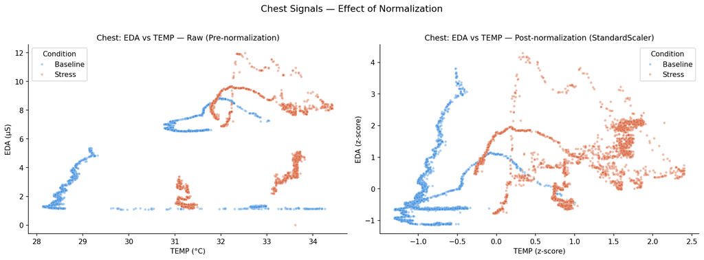

**Normalization on Wrist EDA and TEMP Signals Before vs. After Result**

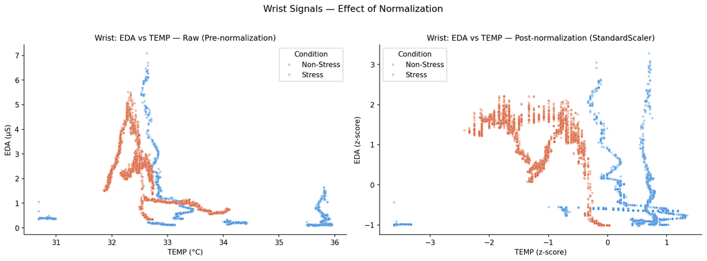

#### Rolling Windows Creation

```python
import pandas as pd
import numpy as np
from pathlib import Path
from concurrent.futures import ThreadPoolExecutor, as_completed
import os

# --------------------------------
# Config
# --------------------------------
ALL_PARTICIPANTS = False

TRAIN_PATH = "wesad_chest_train.csv"
TEST_PATH = "wesad_chest_test.csv"

OUTPUT_DIR = Path("windowed_outputs")
OUTPUT_DIR.mkdir(exist_ok=True)

SIGNAL_COLS = ["ECG", "EDA", "TEMP", "RESP"]
SUBJECT_COL = "subject"
LABEL_COL = "label"

SAMPLING_RATE = 1

WINDOWS = {
    "1min": 60,
    "3min": 180
}

STRIDE = 30

MAX_WORKERS = max(1, os.cpu_count() - 1)


# --------------------------------
# Helpers
# --------------------------------
def compute_zscores(train_df, test_df, signal_cols):
    print("Calculating z-scores from train set...")

    train_df = train_df.copy()
    test_df = test_df.copy()

    for col in signal_cols:
        mean = train_df[col].mean()
        std = train_df[col].std()

        if std == 0 or pd.isna(std):
            print(f"Warning: {col} has std=0 or NaN. Skipping z-score.")
            train_df[f"{col}_z"] = train_df[col]
            test_df[f"{col}_z"] = test_df[col]
        else:
            train_df[f"{col}_z"] = (train_df[col] - mean) / std
            test_df[f"{col}_z"] = (test_df[col] - mean) / std

    print("Finished z-scores.")
    return train_df, test_df


def create_subject_windows(subject, group, window_seconds, stride):
    window_size = window_seconds * SAMPLING_RATE
    rows = []

    group = group.reset_index(drop=True)

    if len(group) < window_size:
        return pd.DataFrame()

    for start in range(0, len(group) - window_size + 1, stride):
        end = start + window_size
        window = group.iloc[start:end]

        row = {
            SUBJECT_COL: subject,
            "window_size_sec": window_seconds,
            "start_idx": start,
            "end_idx": end - 1
        }

        for col in SIGNAL_COLS:
            use_col = f"{col}_z" if f"{col}_z" in window.columns else col

            row[f"{col}_mean"] = window[use_col].mean()
            row[f"{col}_std"] = window[use_col].std()
            row[f"{col}_min"] = window[use_col].min()
            row[f"{col}_max"] = window[use_col].max()

        row[LABEL_COL] = window[LABEL_COL].mode().iloc[0]

        rows.append(row)

    return pd.DataFrame(rows)


def create_windows_parallel(df, window_name, window_seconds, split_name):
    print(f"\nStarting {split_name} {window_name} windowing...")

    grouped = list(df.groupby(SUBJECT_COL))
    results = []

    with ThreadPoolExecutor(max_workers=MAX_WORKERS) as executor:
        futures = {
            executor.submit(
                create_subject_windows,
                subject,
                group,
                window_seconds,
                STRIDE
            ): subject
            for subject, group in grouped
        }

        completed = 0
        total = len(futures)

        for future in as_completed(futures):
            subject = futures[future]
            completed += 1

            try:
                result = future.result()
                results.append(result)

                print(
                    f"[{split_name} {window_name}] "
                    f"Finished {subject} "
                    f"({completed}/{total}) - {len(result)} windows"
                )

            except Exception as e:
                print(f"Error processing {subject}: {e}")

    if results:
        output = pd.concat(results, ignore_index=True)
    else:
        output = pd.DataFrame()

    print(
        f"Finished {split_name} {window_name}: "
        f"{len(output)} total windows"
    )

    return output


def save_outputs(train_windows, test_windows, window_name):
    if ALL_PARTICIPANTS:
        train_path = OUTPUT_DIR / f"train_{window_name}_all.csv"
        test_path = OUTPUT_DIR / f"test_{window_name}_all.csv"

        train_windows.to_csv(train_path, index=False)
        test_windows.to_csv(test_path, index=False)

        print(f"Saved {train_path}")
        print(f"Saved {test_path}")

    else:
        for subject in train_windows[SUBJECT_COL].unique():
            train_subject = train_windows[
                train_windows[SUBJECT_COL] == subject
            ]

            test_subject = test_windows[
                test_windows[SUBJECT_COL] == subject
            ]

            train_path = OUTPUT_DIR / f"train_{window_name}_{subject}.csv"
            test_path = OUTPUT_DIR / f"test_{window_name}_{subject}.csv"

            train_subject.to_csv(train_path, index=False)
            test_subject.to_csv(test_path, index=False)

            print(f"Saved {train_path}")
            print(f"Saved {test_path}")


# --------------------------------
# Main
# --------------------------------
print("Reading train/test CSVs...")
train = pd.read_csv(TRAIN_PATH)
test = pd.read_csv(TEST_PATH)

print(f"Train shape: {train.shape}")
print(f"Test shape: {test.shape}")
print(f"Using {MAX_WORKERS} worker threads.")

if ALL_PARTICIPANTS:
    train, test = compute_zscores(train, test, SIGNAL_COLS)

for window_name, window_seconds in WINDOWS.items():
    train_windows = create_windows_parallel(
        train,
        window_name,
        window_seconds,
        split_name="train"
    )

    test_windows = create_windows_parallel(
        test,
        window_name,
        window_seconds,
        split_name="test"
    )

    save_outputs(train_windows, test_windows, window_name)

print("\nFinished all windowing.")
```

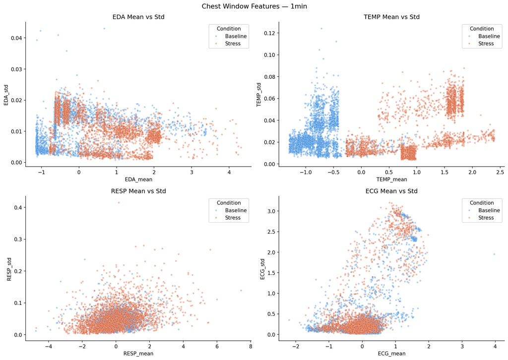

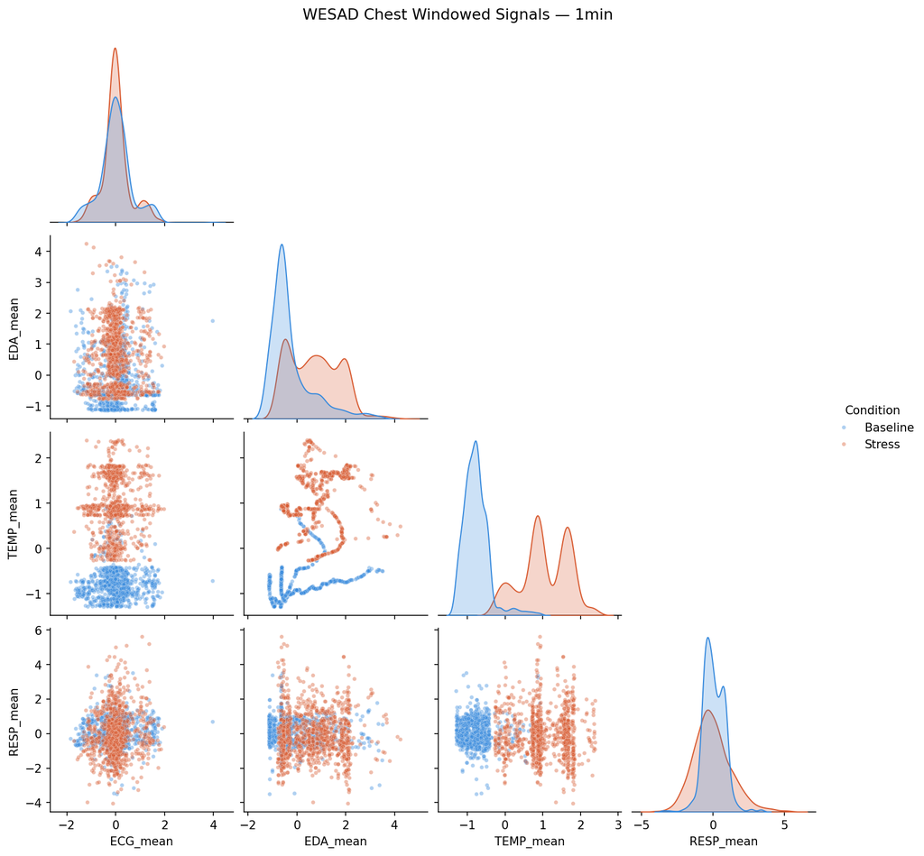

#### Example config.yaml

```yaml
# Configuration file

# Absolute WESAD dataset path
dataset_path: 'C:\Users\vgvau\PycharmProjects\IDC6940_RandomForest\windowed_outputs'

# Processing
multithread: false

# Participants
composite_participants: false # using all participants to train model (NOT default and has limitations)
participants: ["S2","S3","S4"]#, "S3"] # array of participants to predict for

# Variables
variables: ["ECG_mean", "EDA_mean", "TEMP_mean", "RESP_mean"]

# ARIMA parameters, if all are NONE, parameters will be selected using AutoARIMA()
p: 5
d: 0
q: 0
```

#### ARIMA Classification

```python
import os
import pickle

import pandas as pd
import yaml
from matplotlib import pyplot as plt
from sklearn.metrics import roc_auc_score, roc_curve, f1_score, confusion_matrix, precision_score, accuracy_score, \
    recall_score, ConfusionMatrixDisplay, classification_report




def classify_arima_results(arima_results, stress, baseline):
    results = arima_results["predictions"].copy()
    results = results[results["label"].isin([1, 2])].copy()

    baseline_mean = float(baseline["mean"])
    stress_mean = float(stress["mean"])

    def classify(value):
        d_baseline = abs(value - baseline_mean)
        d_stress = abs(value - stress_mean)

        return 2 if d_stress <= d_baseline else 1


    results["predicted_label"] = results["predicted"].apply(classify)

    return results

def compute_metrics(y_true, y_pred):
    return {
        "accuracy": accuracy_score(y_true, y_pred),
        "precision": precision_score(
            y_true,
            y_pred,
            pos_label=2,
            zero_division=0
        ),
        "recall": recall_score(
            y_true,
            y_pred,
            pos_label=2,
            zero_division=0
        ),
        "f1": f1_score(
            y_true,
            y_pred,
            pos_label=2,
            zero_division=0
        ),
        "confusion_matrix": confusion_matrix(
            y_true,
            y_pred,
            labels=[1, 2]
        ).tolist()
    }


def save_confusion_matrix(y_true, y_pred, output_path):
    cm = confusion_matrix(
        y_true,
        y_pred,
        labels=[1, 2]
    )

    display = ConfusionMatrixDisplay(
        confusion_matrix=cm,
        display_labels=["Not stressed", "Stress"]
    )

    display.plot()
    plt.title("ARIMA Stress Classification")
    plt.tight_layout()
    plt.savefig(output_path, dpi=300)
    plt.close()


def save_roc_curve(y_true, stress_scores, output_path):
    # Convert WESAD labels to binary for ROC:
    # baseline/not stressed = 0, stress = 1
    y_true_binary = (pd.Series(y_true) == 2).astype(int)

    # ROC cannot be calculated when only one class is present
    if y_true_binary.nunique() < 2:
        print(
            f"ROC curve not generated for {output_path}: "
            "test data contains only one class."
        )
        return None

    auc_score = roc_auc_score(y_true_binary, stress_scores)
    fpr, tpr, _ = roc_curve(y_true_binary, stress_scores)

    plt.figure()
    plt.plot(fpr, tpr, label=f"ARIMA heuristic, AUC = {auc_score:.3f}")
    plt.plot([0, 1], [0, 1], linestyle="--")
    plt.xlabel("False Positive Rate")
    plt.ylabel("True Positive Rate")
    plt.title("ROC Curve")
    plt.legend()
    plt.tight_layout()
    plt.savefig(output_path, dpi=300)
    plt.close()

    return auc_score


def load_arima_results(path):
    with open(path, "rb") as f:
        data = pickle.load(f)
    return data

def main(config_path):
    # 1. Read in config
    with open(config_path, "r") as file:
        config = yaml.safe_load(file)

    # Read in classification rules
    rules_df = pd.read_csv("classification_rules.csv")

    os.makedirs("plots", exist_ok=True)
    output_dir="plots"

    all_metrics = []


    # 2. Read in participant .pkl

    for participant in config["participants"]:

        for variable in config["variables"]:

            for window in ["1min", "3min"]:
                print(f"\n--- {participant} | {variable} | {window} ---")

                rules = rules_df[
                    (rules_df["subject"] == participant) &
                    (rules_df["variable"] == variable) &
                    (rules_df["window"] == window)
                    ]

                baseline = rules[rules["activity_label"] == 1].iloc[0]
                stress = rules[rules["activity_label"] == 2].iloc[0]

                print(f"Stress Rules: 1 - {baseline} 2 - {stress}")

                # Read ARIMA pickle
                pkl_path = f"arima_results_{participant}_{variable}_{window}.pkl"

                print("Classifying...")
                data = load_arima_results(pkl_path)

                # Classify predictions
                classified = classify_arima_results(
                    arima_results=data,
                    stress = stress,
                    baseline = baseline
                )

                print("Computing metrics...")
                # Metrics
                metric_results = compute_metrics(
                    classified["label"],
                    classified["predicted_label"]
                )

                auc_roc_path = f"{output_dir}/{participant}_{variable}_{window}_roc_auc.png"


                classified_path = f"{output_dir}/{participant}_{variable}_{window}_classified.pkl"


                confusion_matrix_path = f"{output_dir}/{participant}_{variable}_{window}_conf_matrix.png"


                metrics_path = f"{output_dir}/{participant}_{variable}_{window}_metrics.pkl"

                print("Computing AUC ROC...")
                auc_score = save_roc_curve(
                    y_true=classified["label"],
                    stress_scores=classified["predicted"],
                    output_path=auc_roc_path
                )

                metric_results["roc_auc"] = auc_score

                print("Computing Confusion Matrix...")
                save_confusion_matrix(
                    y_true=classified["label"],
                    y_pred=classified["predicted_label"],
                    output_path=confusion_matrix_path
                )

                classified.to_pickle(classified_path)

                with open(metrics_path, "wb") as file:
                    pickle.dump(metric_results, file)

                all_metrics.append({
                    "participant": participant,
                    "variable": variable,
                    "window": window,
                    "accuracy": metric_results["accuracy"],
                    "precision": metric_results["precision"],
                    "recall": metric_results["recall"],
                    "f1": metric_results["f1"],
                    "roc_auc": metric_results["roc_auc"]
                })

                print(metric_results)

                print(
                    classification_report(
                        classified["label"],
                        classified["predicted_label"],
                        labels=[1, 2],
                        target_names=["Not stressed", "Stress"],
                        zero_division=0
                    )
                )

            all_metrics_df = pd.DataFrame(all_metrics)

            all_metrics_df.to_csv(
                "all_classification_metrics.csv",
                index=False
            )

if __name__ == '__main__':
    output = main('config.yaml')
```

#### Rolling windows for ARIMA

```python
import numpy as np
import pandas as pd
from statsmodels.tsa.arima.model import ARIMA
from sklearn.metrics import mean_absolute_error, mean_squared_error

def get_classification_rules(df, subject, activity_label, variables):
    # Compute participant-specific classification rules for selected variables.

    subset = df[
        (df["subject"] == subject) &
        (df["label"] == activity_label)
    ]

    rules = []

    for var in variables:
        mean = subset[var].mean()
        std = subset[var].std()

        rules.append({
            "subject": subject,
            "activity_label": activity_label,
            "variable": var,
            "mean": mean,
            "std": std,
            "min": subset[var].min(),
            "max": subset[var].max(),
            "lower_1sd": mean - std,
            "upper_1sd": mean + std
        })

    return pd.DataFrame(rules)

try:
    from pmdarima import auto_arima
except ImportError:
    auto_arima = None


def compute_continuous_scores(y_true, y_pred) -> dict:
    y_true = np.array(y_true)
    y_pred = np.array(y_pred)

    mae = mean_absolute_error(y_true, y_pred)
    mse = mean_squared_error(y_true, y_pred)
    rmse = np.sqrt(mse)

    # Avoid divide-by-zero issues
    nonzero_mask = y_true != 0
    if nonzero_mask.any():
        mape = np.mean(
            np.abs((y_true[nonzero_mask] - y_pred[nonzero_mask]) / y_true[nonzero_mask])
        ) * 100
    else:
        mape = np.nan

    return {
        "MAE": mae,
        "MSE": mse,
        "RMSE": rmse,
        "MAPE": mape
    }

def run_arima(train_df, test_df, target_col: str, p=None, d=None, q=None):
    y_train = train_df[target_col].dropna()
    y_test = test_df[target_col].dropna()

    order = (p, d, q)

    print(f"Using ARIMA order: {order}")

    model = ARIMA(y_train, order=order)
    fitted_model = model.fit()

    predictions = []

    for actual in y_test:
        pred = fitted_model.forecast(steps=1).iloc[0]
        predictions.append(pred)

        fitted_model = fitted_model.append(
            [actual],
            refit=False
        )

    predictions = pd.Series(predictions, index=y_test.index)

    scores = compute_continuous_scores(
        y_true=y_test,
        y_pred=predictions
    )

    results_df = pd.DataFrame({
        "subject": test_df.loc[y_test.index, "subject"].values,
        "label": test_df.loc[y_test.index, "label"].values,
        "actual": y_test.values,
        "predicted": predictions.values
    })


    return {
        "model": fitted_model,
        "order": order,
        "predictions": results_df,
        "scores": scores
    }
```

```python
import pickle
from pathlib import Path

import pandas as pd
import yaml

from model_pipeline.ARIMA_model import run_arima, get_classification_rules
from plotting_utils.arima_plotting_helpers import plot_arima_prediction


def main(config_path):
    # Read in config params

    with open(config_path, "r") as file:
        config = yaml.safe_load(file)

    # df = build_dataset(config)

    rolling_window_dir = Path(config["dataset_path"])

    p = config.get("p")
    d = config.get("d")
    q = config.get("q")

    # YAML "None" may load as string, so clean it
    p = None if p in ["None", "none", None] else int(p)
    d = None if d in ["None", "none", None] else int(d)
    q = None if q in ["None", "none", None] else int(q)

    # target_col = "ECG_mean"

    rules_df = pd.DataFrame({})


    if config["composite_participants"]:
        for target_col in config["variables"]:

            train_1min_df = pd.read_csv(rolling_window_dir / f"train_1min_all.csv")
            train_3min_df = pd.read_csv(rolling_window_dir / f"train_3min_all.csv")

            test_1min_df = pd.read_csv(rolling_window_dir / f"test_1min_all.csv")
            test_3min_df = pd.read_csv(rolling_window_dir / f"test_3min_all.csv")

            print(f"[--Plotting ARIMA Prediction at 1 Min Windows--]")
            arima_results_1min = run_arima(
                train_df=train_1min_df,
                test_df=test_1min_df,
                target_col=target_col, # TODO: change to use all feature vars
                p=p,
                d=d,
                q=q
            )
            print(f"[--Plotting ARIMA Prediction at 1 Min Windows--]")
            plot_arima_prediction(
                test_df=test_1min_df,
                arima_results=arima_results_1min,
                target_col=target_col,
                title="ARIMA ECG Prediction - 1 Minute Window"
            )
            print(f"[--Running ARIMA Prediction at 3 Min Windows--]")
            arima_results_3min = run_arima(
                train_df=train_3min_df,
                test_df=test_3min_df,
                target_col=target_col,  # TODO: change to use all feature vars
                p=p,
                d=d,
                q=q
            )
            print(f"[--Plotting ARIMA Prediction at 3 Min Windows--]")
            plot_arima_prediction(
                test_df=test_3min_df,
                arima_results=arima_results_3min,
                target_col=target_col,
                title="ARIMA ECG Prediction - 3 Minute Window"
            )

            print("Composite participant mode enabled")
            print("[--1 MINUTE ROLLING WINDOW--]")
            print(f"Train shape 1min: {train_1min_df.shape}")
            print(f"Test shape 1min: {test_1min_df.shape}")
            print(arima_results_1min["scores"])
            print()
            print("[--3 MINUTE ROLLING WINDOW--]")
            print(f"Train shape 3min: {train_1min_df.shape}")
            print(f"Test shape 3min: {test_1min_df.shape}")
            print(arima_results_1min["scores"])


            print(arima_results_1min["scores"])
            output = {}
            output[target_col]["1min"]= arima_results_1min
            output[target_col]["3min"] = arima_results_3min



            with open(f"arima_results_all_{target_col}_5_0_0_7-5_9-39.pkl", "wb") as f:
                pickle.dump(output, f)
            return output

    else:
        # Individual participant mode
        # participant_splits = {}


        for participant in config["participants"]:
            for target_col in config["variables"]:
                # participant_splits[participant] = {
                #     target_col: {}
                # }
                participant_train_1min_df = pd.read_csv(rolling_window_dir / f"train_1min_{participant}.csv")
                participant_test_1min_df = pd.read_csv(rolling_window_dir / f"test_1min_{participant}.csv")


                print(f"[--Running {participant} ARIMA Prediction for {target_col} at 1 Min Windows--]")
                arima_results_1min = run_arima(
                    train_df=participant_train_1min_df,
                    test_df=participant_test_1min_df,
                    target_col=target_col,
                    p=p,
                    d=d,
                    q=q
                )

                print(f"[--Plotting {participant} ARIMA Prediction for {target_col} at 1 Min Windows--]")
                plot_arima_prediction(
                    test_df=participant_test_1min_df,
                    arima_results=arima_results_1min,
                    target_col=target_col,
                    title="ARIMA ECG Prediction - 1 Minute Window"
                )

                with open(f"arima_results_{participant}_{target_col}_1min.pkl", "wb") as f:
                    pickle.dump(arima_results_1min, f)

                participant_rules = pd.concat([
                    get_classification_rules(
                        participant_train_1min_df,
                        participant,
                        activity_label=1,
                        variables=[target_col]
                    ),
                    get_classification_rules(
                        participant_train_1min_df,
                        participant,
                        activity_label=2,
                        variables=[target_col]
                    )
                ], ignore_index=True)

                participant_rules["window"] = "1min"

                rules_df = pd.concat(
                    [rules_df, participant_rules],
                    ignore_index=True
                )


                participant_train_3min_df = pd.read_csv(rolling_window_dir / f"train_3min_{participant}.csv")
                participant_test_3min_df = pd.read_csv(rolling_window_dir / f"test_3min_{participant}.csv")

                print(f"[--Running {participant} ARIMA Prediction for {target_col} at 3 Min Windows--]")
                arima_results_3min = run_arima(
                    train_df=participant_train_3min_df,
                    test_df=participant_test_3min_df,
                    target_col=target_col,
                    p=p,
                    d=d,
                    q=q
                )

                print(f"[--Plotting {participant} ARIMA Prediction for {target_col} at 3 Min Windows--]")
                plot_arima_prediction(
                    test_df=participant_test_3min_df,
                    arima_results=arima_results_3min,
                    target_col=target_col,
                    title="ARIMA ECG Prediction - 3 Minute Window"
                )

                with open(f"arima_results_{participant}_{target_col}_3min.pkl", "wb") as f:
                    pickle.dump(arima_results_3min, f)

                participant_rules = pd.concat([
                    get_classification_rules(
                        participant_train_3min_df,
                        participant,
                        activity_label=1,
                        variables=[target_col]
                    ),
                    get_classification_rules(
                        participant_train_3min_df,
                        participant,
                        activity_label=2,
                        variables=[target_col]
                    )
                ], ignore_index=True)

                participant_rules["window"] = "3min"

                rules_df = pd.concat(
                    [rules_df, participant_rules],
                    ignore_index=True
                )

                print("[--1 MINUTE ROLLING WINDOW--]")
                print(f"Train shape 1min: {participant_train_1min_df.shape}")
                print(f"Test shape 1min: {participant_test_1min_df.shape}")
                print(arima_results_1min["scores"])
                print()
                print("[--3 MINUTE ROLLING WINDOW--]")
                print(f"Train shape 3min: {participant_train_3min_df.shape}")
                print(f"Test shape 3min: {participant_train_3min_df.shape}")
                print(arima_results_3min["scores"])

    rules_df.to_csv("classification_rules.csv")





if __name__ == '__main__':
    main('config.yaml')
```

#### Rolling windows for Random Forest

```python
# Load Data

import pandas as pd
import numpy as np
from pathlib import Path

from sklearn.ensemble import RandomForestClassifier
from sklearn.metrics import (
    accuracy_score,
    precision_score,
    recall_score,
    f1_score,
    roc_auc_score,
    roc_curve,
    confusion_matrix
)

# -------------------------------------------------------
# Configuration
# -------------------------------------------------------

WINDOW_DIR = Path("windowed_outputs")

OUTPUT_DIR = Path("rf_window_results")
OUTPUT_DIR.mkdir(exist_ok=True)

ROC_DIR = OUTPUT_DIR / "roc_curves"
ROC_DIR.mkdir(exist_ok=True)

CM_DIR = OUTPUT_DIR / "confusion_matrices"
CM_DIR.mkdir(exist_ok=True)

WINDOWS = ["1min", "3min"]

SIGNALS = ["ECG", "EDA", "TEMP", "RESP"]

# -------------------------------------------------------
# Find Subjects
# -------------------------------------------------------

subjects = sorted({
    f.stem.split("_")[-1]
    for f in WINDOW_DIR.glob("train_*_S*.csv")
})

print("Subjects:", subjects)

results = []

# -------------------------------------------------------
# Loop over windows
# -------------------------------------------------------

for window in WINDOWS:

    print(f"\n{'='*60}")
    print(f"Processing {window}")
    print(f"{'='*60}")

    for subject in subjects:

        train_file = WINDOW_DIR / f"train_{window}_{subject}.csv"
        test_file = WINDOW_DIR / f"test_{window}_{subject}.csv"

        if not train_file.exists() or not test_file.exists():
            print(f"Skipping {subject}")
            continue



        train = pd.read_csv(train_file)
        test = pd.read_csv(test_file)

        # Keep only Baseline (1) and Stress (2)
        train = train[train["label"].isin([1, 2])].copy()
        test = test[test["label"].isin([1, 2])].copy()

        # Convert to binary classification
        # Baseline = 0, Stress = 1
        train["label"] = train["label"].map({1: 0, 2: 1})
        test["label"] = test["label"].map({1: 0, 2: 1})

        for signal in SIGNALS:

            feature_cols = [
                f"{signal}_mean",
                f"{signal}_std",
                f"{signal}_min",
                f"{signal}_max"
            ]

            X_train = train[feature_cols]
            y_train = train["label"]

            X_test = test[feature_cols]
            y_test = test["label"]

            # -------------------------------------------------------
            # Train RF
            # -------------------------------------------------------

            rf = RandomForestClassifier(
                n_estimators=100,
                random_state=42,
                n_jobs=-1
            )

            rf.fit(X_train, y_train)

            y_pred = rf.predict(X_test)
            y_prob = rf.predict_proba(X_test)[:, 1]

            # -------------------------------------------------------
            # Metrics
            # -------------------------------------------------------

            acc = accuracy_score(y_test, y_pred)

            prec = precision_score(
                y_test,
                y_pred,
                average="macro",
                zero_division=0
            )

            rec = recall_score(
                y_test,
                y_pred,
                average="macro",
                zero_division=0
            )

            f1 = f1_score(
                y_test,
                y_pred,
                average="macro"
            )

            auc = roc_auc_score(y_test, y_prob)

            # -------------------------------------------------------
            # ROC Curve
            # -------------------------------------------------------

            fpr, tpr, thresholds = roc_curve(
                y_test,
                y_prob
            )

            roc_df = pd.DataFrame({
                "FPR": fpr,
                "TPR": tpr,
                "Threshold": thresholds
            })

            roc_df.to_csv(
                ROC_DIR /
                f"roc_{signal}_{window}_{subject}.csv",
                index=False
            )

            # -------------------------------------------------------
            # Confusion Matrix
            # -------------------------------------------------------

            cm = confusion_matrix(y_test, y_pred)

            cm_df = pd.DataFrame(
                cm,
                index=["Actual_0", "Actual_1"],
                columns=["Pred_0", "Pred_1"]
            )

            cm_df.to_csv(
                CM_DIR /
                f"confusion_{signal}_{window}_{subject}.csv"
            )

            # -------------------------------------------------------
            # Results Summary
            # -------------------------------------------------------

            results.append({
                "signal": signal,
                "subject": subject,
                "window": window,
                "accuracy": round(acc, 4),
                "precision": round(prec, 4),
                "recall": round(rec, 4),
                "f1": round(f1, 4),
                "roc_auc": round(auc, 4)
            })

            print(
                f"{subject:>3} | "
                f"{signal:<4} | "
                f"{window:<4} | "
                f"AUC={auc:.3f} "
                f"F1={f1:.3f}"
            )

# -------------------------------------------------------
# Save Summary
# -------------------------------------------------------

results_df = pd.DataFrame(results)

results_df = results_df[
    [
        "signal",
        "subject",
        "window",
        "accuracy",
        "precision",
        "recall",
        "f1",
        "roc_auc"
    ]
]

results_df.to_csv(
    OUTPUT_DIR / "rf_window_results.csv",
    index=False
)

print("\nFinished.")
print(results_df)
```

```python
# Load Data


import joblib
import pandas as pd
import numpy as np
from sklearn.ensemble import RandomForestClassifier
from sklearn.metrics import classification_report, f1_score, precision_score, recall_score

print("=== Chest RF Pipeline (Lags + 1-min + 3-min Rolling Windows) ===")

# -------------------------------------------------------
# 1. LOAD PRE-SPLIT, PRE-NORMALIZED CHEST FILES
# -------------------------------------------------------
print("Loading chest data splits...")
train_df = pd.read_csv("wesad_chest_train.csv")
test_df  = pd.read_csv("wesad_chest_test.csv")



FS = 700  # chest sensor Hz

# -------------------------------------------------------
# 2. FEATURE ENGINEERING
# -------------------------------------------------------
def engineer_chest_features(df, fs=700):
    """
    Per-subject feature engineering for chest signals (no leakage):
      - Lag features  : t-1 to t-4        (raw signal history)
      - 1-min rolling : mean + std         (42,000 samples @ 700Hz)
      - 3-min rolling : mean + std         (126,000 samples @ 700Hz)

    Same 1-min and 3-min window durations as wrist RF for consistent
    cross-sensor comparison. Sample counts differ due to sampling rate:
      Wrist 1-min = 240 samples   | Chest 1-min = 42,000 samples
      Wrist 3-min = 720 samples   | Chest 3-min = 126,000 samples
    """
    valid_features = [f for f in ['ECG', 'EDA', 'TEMP', 'RESP'] if f in df.columns]
    print(f" -> Chest channels found: {valid_features}")

    win_1min = fs * 60           # 42,000 samples
    win_3min = fs * 60 * 3      # 126,000 samples

    print(f" -> 1-min window: {win_1min:,} samples")
    print(f" -> 3-min window: {win_3min:,} samples")
    print(f" -> Note: Large windows at 700Hz — may take 15-30 mins...")

    groups = []
    for subject, group in df.groupby('subject'):
        print(f"    Engineering features for {subject}...")
        g = group.sort_index().copy()

        for col in valid_features:
            # Lag features
            for lag in range(1, 5):
                g[f'{col}_lag_{lag}'] = g[col].shift(lag)

            # 1-min rolling (acute stress onset)
            g[f'{col}_roll1min_mean'] = (
                g[col].rolling(window=win_1min, min_periods=1).mean()
            )
            g[f'{col}_roll1min_std'] = (
                g[col].rolling(window=win_1min, min_periods=2).std()
            )

            # 3-min rolling (sustained physiological arousal)
            g[f'{col}_roll3min_mean'] = (
                g[col].rolling(window=win_3min, min_periods=1).mean()
            )
            g[f'{col}_roll3min_std'] = (
                g[col].rolling(window=win_3min, min_periods=2).std()
            )

        groups.append(g.dropna())
        print(f"    {subject} done.")

    return pd.concat(groups, ignore_index=True)


print("\nEngineering chest features (this will take a while)...")
train_engineered = engineer_chest_features(train_df)
test_engineered  = engineer_chest_features(test_df)

feature_columns = [
    c for c in train_engineered.columns
    if c not in ['subject', 'label']
]
print(f"\n -> Total feature columns: {len(feature_columns)}")
print(f"    {feature_columns}")

# -------------------------------------------------------
# 3. PER-SUBJECT TRAINING LOOP
# -------------------------------------------------------
results_summary = []
all_importances = []

for subject, group in train_engineered.groupby('subject'):
    print(f"\n{'='*50}")
    print(f"Training Chest RF for {subject}...")

    X_train = group[feature_columns]
    y_train = group['label']

    test_group = test_engineered[test_engineered['subject'] == subject]
    if test_group.empty:
        print(f" [SKIP] No test data found for {subject}")
        continue

    X_test = test_group[feature_columns]
    y_test = test_group['label']

    print(f" -> Train: {X_train.shape} | Test: {X_test.shape}")
    print(f" -> Train labels: {y_train.value_counts().to_dict()}")
    print(f" -> Test  labels: {y_test.value_counts().to_dict()}")

    rf_model = RandomForestClassifier(
    n_estimators=100,
    random_state=42,
    n_jobs=-1
    )
    rf_model.fit(X_train, y_train)
    y_pred = rf_model.predict(X_test)

    macro_f1   = f1_score(y_test, y_pred, average='macro')
    macro_prec = precision_score(y_test, y_pred, average='macro', zero_division=0)
    macro_rec  = recall_score(y_test, y_pred, average='macro', zero_division=0)

    print(f"\n[{subject}] Precision : {macro_prec:.4f}")
    print(f"[{subject}] Recall    : {macro_rec:.4f}")
    print(f"[{subject}] F1-Score  : {macro_f1:.4f}")
    print(classification_report(
        y_test, y_pred,
        labels=[0, 1],
        target_names=['Non-Stress', 'Stress'],
        zero_division=0
    ))

    # Feature importance
    importances = pd.DataFrame({
        'subject':    subject,
        'feature':    feature_columns,
        'importance': rf_model.feature_importances_
    }).sort_values('importance', ascending=False)

    print(f"Top 10 features for {subject}:")
    print(importances.head(10).to_string(index=False))
    importances.to_csv(f"chest_feature_importance_{subject}.csv", index=False)
    all_importances.append(importances)

    model_filename = f"rf_chest_{subject}_rolling.pkl"
    joblib.dump(rf_model, model_filename)
    print(f" Saved: {model_filename}")

    results_summary.append({
        'subject':   subject,
        'sensor':    'chest',
        'precision': round(macro_prec, 4),
        'recall':    round(macro_rec, 4),
        'f1_macro':  round(macro_f1, 4)
    })

# -------------------------------------------------------
# 4. SUMMARY TABLE
# -------------------------------------------------------
print(f"\n{'='*50}")
print("=== Chest RF Results Summary ===")
summary_df = pd.DataFrame(results_summary)
print(summary_df.to_string(index=False))
summary_df.to_csv("rf_chest_rolling_results.csv", index=False)
print("Saved: rf_chest_rolling_results.csv")

# -------------------------------------------------------
# 5. AGGREGATE FEATURE IMPORTANCE
# -------------------------------------------------------
print("\n=== Chest Aggregate Feature Importance ===")
all_imp_df = pd.concat(all_importances, ignore_index=True)
agg_imp = (
    all_imp_df.groupby('feature')['importance']
    .mean()
    .reset_index()
    .sort_values('importance', ascending=False)
)
print(agg_imp.to_string(index=False))
agg_imp.to_csv("chest_feature_importance_aggregate.csv", index=False)
print("Saved: chest_feature_importance_aggregate.csv")

print("\n=== Chest RF Complete ===")
```

#### Rolling windows for RandomForest

| Signal | Subject | RF Accuracy | RF Precision | RF Recall | RF F1 |
| --- | --- | --- | --- | --- | --- |
| ECG | S2 | 0.7890 | 0.7703 | 0.7569 | 0.7624 |
| ECG | S3 | 0.8920 | 0.9036 | 0.8620 | 0.8770 |
| ECG | S4 | 0.8359 | 0.8232 | 0.8138 | 0.8180 |
| EDA | S2 | 0.0257 | 0.0300 | 0.0262 | 0.0257 |
| EDA | S3 | 0.7562 | 0.8622 | 0.6609 | 0.6635 |
| EDA | S4 | 1.0000 | 1.0000 | 1.0000 | 1.0000 |
| RESP | S2 | 0.7325 | 0.7066 | 0.6812 | 0.6886 |
| RESP | S3 | 0.7746 | 0.7861 | 0.7124 | 0.7259 |
| RESP | S4 | 0.7413 | 0.7197 | 0.6935 | 0.7013 |
| TEMP | S2 | 0.6936 | 0.7665 | 0.7644 | 0.6936 |
| TEMP | S3 | 0.9521 | 0.9652 | 0.9334 | 0.9463 |
| TEMP | S4 | 0.9549 | 0.9435 | 0.9651 | 0.9520 |

*Table 1: Random Forest chest sensor classification results using rolling window features at 1min intervals (ECG, EDA, TEMP, RESP at 700Hz).*

| Signal | Subject | RF Accuracy | RF Precision | RF Recall | RF F1 |
| --- | --- | --- | --- | --- | --- |
| ECG | S2 | 0.8429 | 0.8282 | 0.8249 | 0.8265 |
| ECG | S3 | 0.9587 | 0.9625 | 0.9479 | 0.9545 |
| ECG | S4 | 0.9101 | 0.8970 | 0.9139 | 0.9039 |
| EDA | S2 | 0.0389 | 0.0387 | 0.0470 | 0.0387 |
| EDA | S3 | 0.7784 | 0.8707 | 0.6920 | 0.7038 |
| EDA | S4 | 1.0000 | 1.0000 | 1.0000 | 1.0000 |
| RESP | S2 | 0.7470 | 0.7233 | 0.7023 | 0.7094 |
| RESP | S3 | 0.7835 | 0.7935 | 0.7252 | 0.7394 |
| RESP | S4 | 0.7560 | 0.7375 | 0.7104 | 0.7188 |
| TEMP | S2 | 0.6800 | 0.7611 | 0.7539 | 0.6799 |
| TEMP | S3 | 0.9509 | 0.9644 | 0.9317 | 0.9449 |
| TEMP | S4 | 0.9485 | 0.9364 | 0.9601 | 0.9453 |

*Table 2: Random Forest chest sensor classification results using rolling window features at 3min intervals (ECG, EDA, TEMP, RESP at 700Hz).*

#### Rolling windows for ARIMA Prediction

| Signal | Subject | MAE | MSE | RMSE | MAPE |
| --- | --- | --- | --- | --- | --- |
| ECG | S2 | 0.281 | 0.186 | 0.432 | 175.634 |
| ECG | S3 | 0.247 | 0.154 | 0.392 | 193.028 |
| ECG | S4 | 0.197 | 0.127 | 0.357 | 200.785 |
| EDA | S2 | 0.003 | 0.000 | 0.014 | 0.421 |
| EDA | S3 | 0.002 | 0.001 | 0.031 | 1.100 |
| EDA | S4 | 1.036 | 1.541 | 1.241 | 101.279 |
| RESP | S2 | 0.006 | 0.001 | 0.032 | 4.095 |
| RESP | S3 | 0.009 | 0.001 | 0.035 | 18.387 |
| RESP | S4 | 0.009 | 0.002 | 0.044 | 5.240 |
| TEMP | S2 | 0.003 | 0.002 | 0.044 | 0.493 |
| TEMP | S3 | 0.002 | 0.001 | 0.028 | 0.593 |
| TEMP | S4 | 0.707 | 1.011 | 1.005 | 101.087 |

*Table 3: ARIMA error metrics for 1 min rolling windows.*

| Signal | Subject | MAE | MSE | RMSE | MAPE |
| --- | --- | --- | --- | --- | --- |
| ECG | S2 | 0.118 | 0.029 | 0.171 | 81.483 |
| ECG | S3 | 0.096 | 0.022 | 0.148 | 147.274 |
| ECG | S4 | 0.079 | 0.019 | 0.139 | 127.707 |
| EDA | S2 | 0.001 | 0.000 | 0.009 | 0.191 |
| EDA | S3 | 0.001 | 0.001 | 0.022 | 0.445 |
| EDA | S4 | 0.001 | 0.001 | 0.033 | 0.212 |
| RESP | S2 | 0.003 | 0.001 | 0.026 | 3.039 |
| RESP | S3 | 0.004 | 0.001 | 0.028 | 2.430 |
| RESP | S4 | 0.004 | 0.002 | 0.045 | 2.162 |
| TEMP | S2 | 0.001 | 0.002 | 0.040 | 0.230 |
| TEMP | S3 | 0.001 | 0.001 | 0.025 | 0.286 |
| TEMP | S4 | 641412.983 | 411410614800.562 | 641412.983 | 214480410.853 |

*Table 4: ARIMA error metrics for 3 min rolling windows.*

**ARIMA Prediction for S3 ECG (3min)**

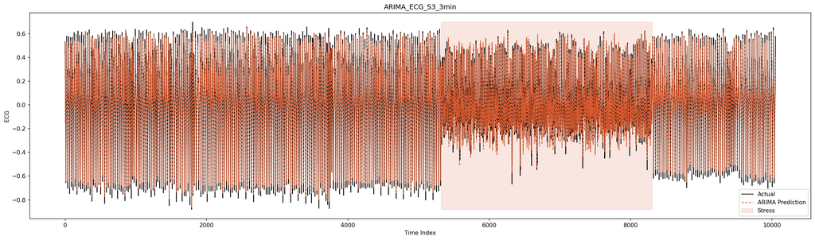

**ARIMA Prediction for S2 EDA (1min)**

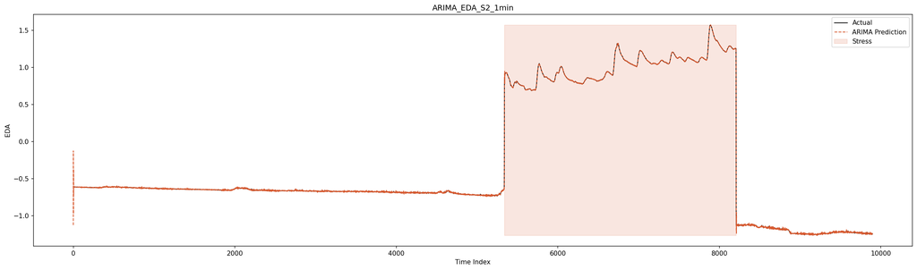

**ARIMA Prediction for S4 RESP (3min)**

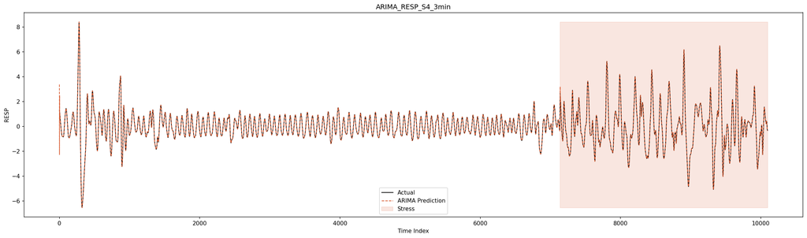

**ARIMA Prediction for S3 TEMP (1min)**

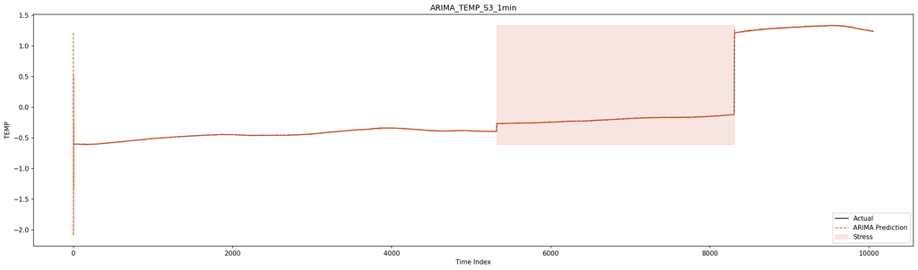

### ARIMA vs RF Classification Results

1-Minute RF vs. ARIMA Classification Results

| Signal | Subject | RF Accuracy | ARIMA Accuracy | RF Precision | ARIMA Precision | RF Recall | ARIMA Recall | RF F1 | ARIMA F1 |
| --- | --- | --- | --- | --- | --- | --- | --- | --- | --- |
| ECG | S2 | 0.7890 | 0.5680 | 0.7703 | 0.3874 | 0.7569 | 0.4052 | 0.7624 | 0.3961 |
| ECG | S3 | 0.8920 | 0.4559 | 0.9036 | 0.3552 | 0.8620 | 0.6299 | 0.8770 | 0.4543 |
| ECG | S4 | 0.8359 | 0.4419 | 0.8232 | 0.3351 | 0.8138 | 0.5858 | 0.8180 | 0.4263 |
| EDA | S2 | 0.0257 | 0.0001 | 0.0300 | 0.0002 | 0.0262 | 0.0003 | 0.0257 | 0.0002 |
| EDA | S3 | 0.7562 | 0.7434 | 0.8622 | 0.9977 | 0.6609 | 0.2870 | 0.6635 | 0.4458 |
| EDA | S4 | 1.0000 | 0.6459 | 1.0000 | 0.0000 | 1.0000 | 0.0000 | 1.0000 | 0.0000 |
| RESP | S2 | 0.7325 | 0.4946 | 0.7066 | 0.3332 | 0.6812 | 0.4446 | 0.6886 | 0.3809 |
| RESP | S3 | 0.7746 | 0.4948 | 0.7861 | 0.3728 | 0.7124 | 0.5941 | 0.7259 | 0.4582 |
| RESP | S4 | 0.7413 | 0.4984 | 0.7197 | 0.3584 | 0.6935 | 0.5270 | 0.7013 | 0.4266 |
| TEMP | S2 | 0.6936 | 0.6769 | 0.7665 | 0.5197 | 0.7644 | 1.0000 | 0.6936 | 0.6840 |
| TEMP | S3 | 0.9521 | 0.6403 | 0.9652 | 0.0000 | 0.9334 | 0.0000 | 0.9463 | 0.0000 |
| TEMP | S4 | 0.9549 | 0.6459 | 0.9435 | 0.0000 | 0.9651 | 0.0000 | 0.9520 | 0.0000 |

*Table 5: Random Forest and ARIMA chest sensor classification results using rolling window features at 1min intervals (ECG, EDA, TEMP, RESP at 700Hz).*

### 3-Minute RF vs. ARIMA Classification Results

| Signal | Subject | RF Accuracy | ARIMA Accuracy | RF Precision | ARIMA Precision | RF Recall | ARIMA Recall | RF F1 | ARIMA F1 |
| --- | --- | --- | --- | --- | --- | --- | --- | --- | --- |
| ECG | S2 | 0.8429 | 0.5591 | 0.8282 | 0.3820 | 0.8249 | 0.4220 | 0.8265 | 0.4010 |
| ECG | S3 | 0.9587 | 0.5721 | 0.9625 | 0.4291 | 0.9479 | 0.5750 | 0.9545 | 0.4915 |
| ECG | S4 | 0.9101 | 0.4343 | 0.8970 | 0.3194 | 0.9139 | 0.5287 | 0.9039 | 0.3982 |
| EDA | S2 | 0.0389 | 0.0000 | 0.0387 | 0.0000 | 0.0470 | 0.0000 | 0.0387 | 0.0000 |
| EDA | S3 | 0.7784 | 0.7427 | 0.8707 | 0.9988 | 0.6920 | 0.2847 | 0.7038 | 0.4431 |
| EDA | S4 | 1.0000 | 0.9999 | 1.0000 | 0.9997 | 1.0000 | 1.0000 | 1.0000 | 0.9998 |
| RESP | S2 | 0.7470 | 0.4951 | 0.7233 | 0.3341 | 0.7023 | 0.4467 | 0.7094 | 0.3823 |
| RESP | S3 | 0.7835 | 0.4952 | 0.7935 | 0.3729 | 0.7252 | 0.5928 | 0.7394 | 0.4578 |
| RESP | S4 | 0.7560 | 0.4987 | 0.7375 | 0.3585 | 0.7104 | 0.5270 | 0.7188 | 0.4267 |
| TEMP | S2 | 0.6800 | 0.6768 | 0.7611 | 0.5197 | 0.7539 | 1.0000 | 0.6799 | 0.6840 |
| TEMP | S3 | 0.9509 | 0.6405 | 0.9644 | 0.6667 | 0.9317 | 0.0007 | 0.9449 | 0.0013 |
| TEMP | S4 | 0.9485 | 0.3540 | 0.9364 | 0.3540 | 0.9601 | 1.0000 | 0.9453 | 0.5229 |

*Table 6: Random Forest and ARIMA chest sensor classification results using rolling window features at 3min intervals (ECG, EDA, TEMP, RESP at 700Hz).*

### Model Comparison Figures (3-minute Window)

Overall the Random Forest model performed better than the ARIMA and classification for most signals and participants, with some interesting behaviors that emerged due to the nature of each physiological signal.

ARIMA

Random Forest

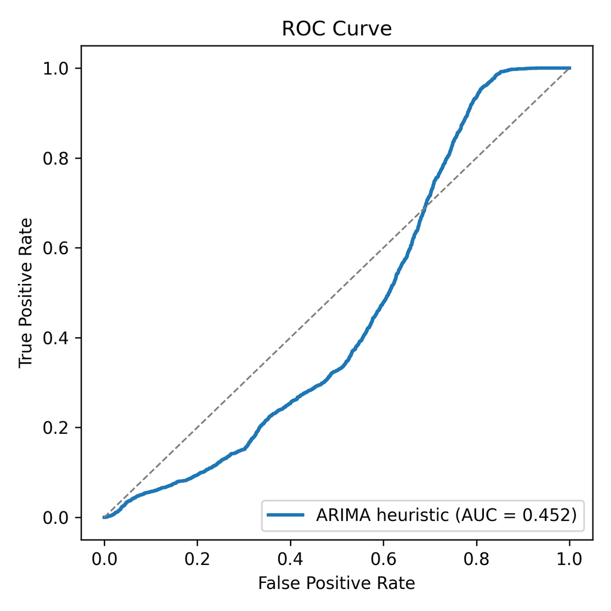

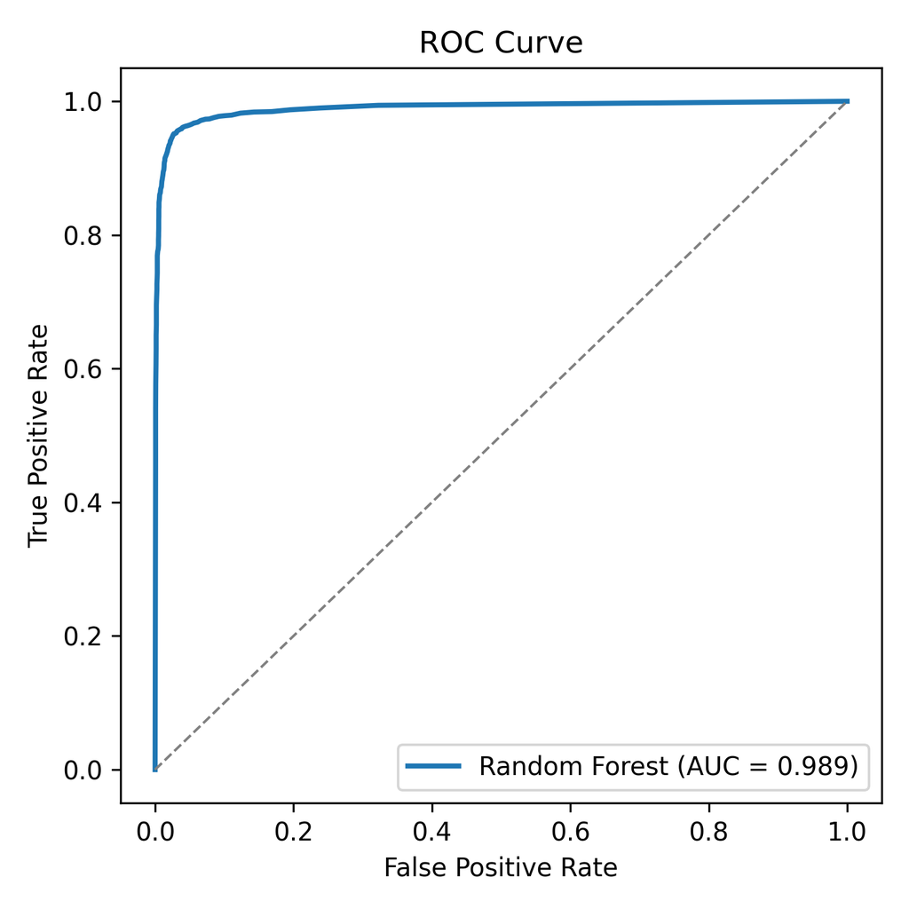

**(a) ARIMA ROC Curve**

**(b) Random Forest ROC Curve**

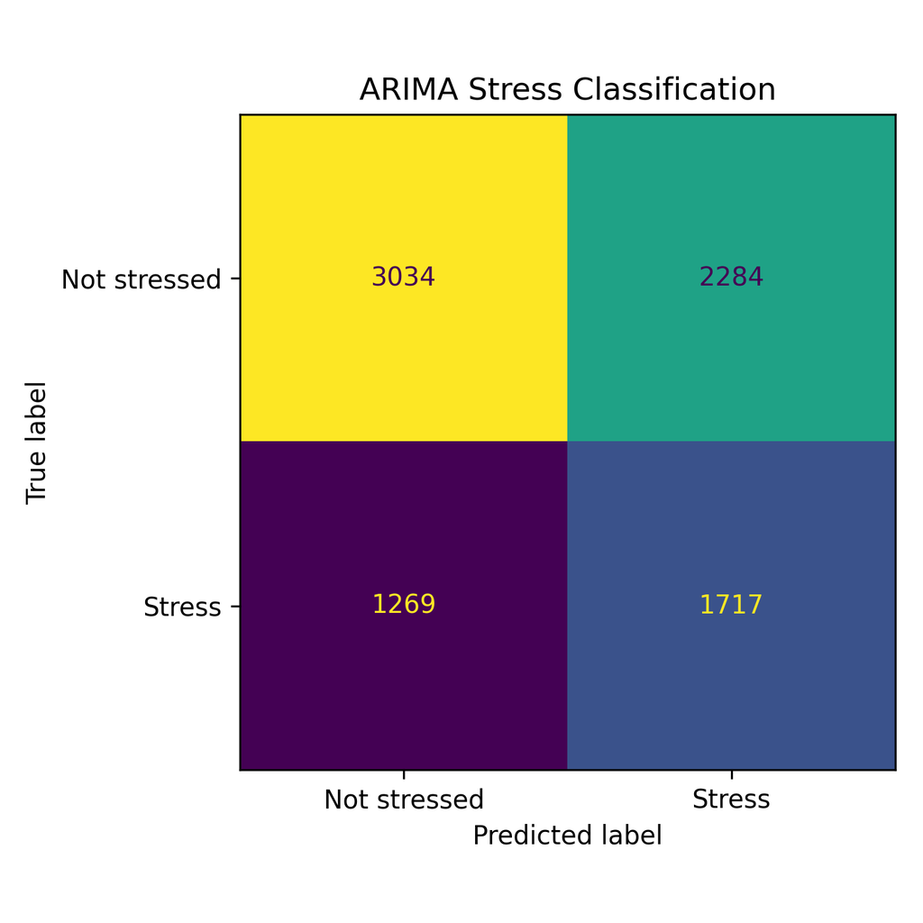

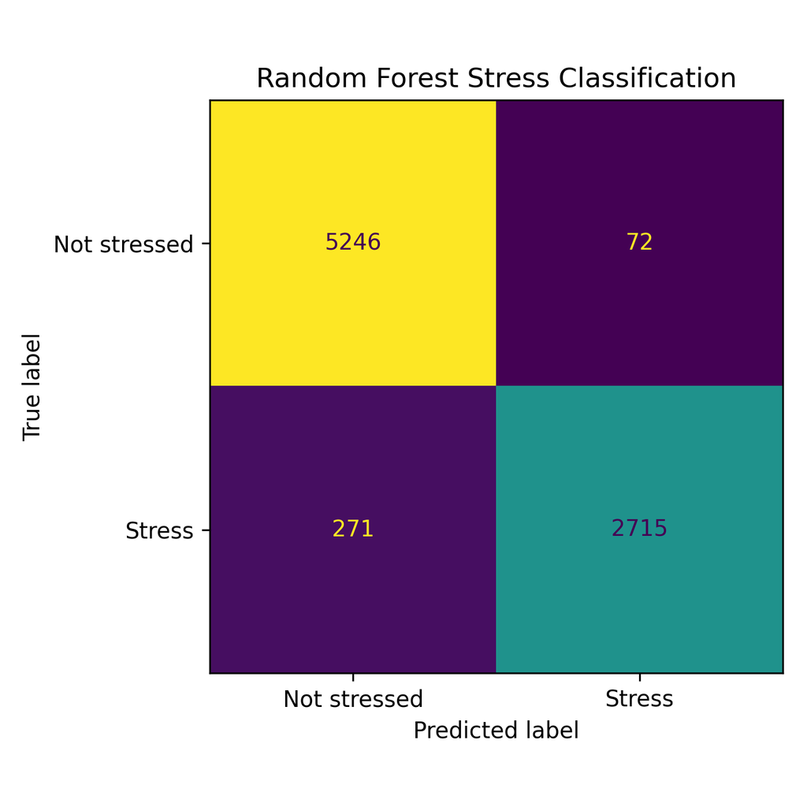

**(c) ARIMA Confusion Matrix**

**(d) Random Forest Confusion Matrix**

*Figure A. Comparison of ARIMA and Random Forest performance for ECG (Subject S3) using a 3-minute rolling window.*

As expected, the ARIMA did not perform as well as Random Forest when predicting ECG, even with the improved prediction from longer rolling windows. The example above shows how signals with a complex temporal patterns are harder to predict for a univariate forecasting model like ARIMA. This resulted in the predicted values not having a meaningful separation between baseline and stress state for accurate classification using nearest-means.

As observed by the signals with less complexity, the ARIMA-based classification performes better with a more distince difference in baseline and stress state. A useful metric to forecast with in next steps would be HR and HRV, instead of raw ECG. HR and HRV typically show more obvious physiological changes when in stress state, and classification rules using nearest mean may be more meaningful for detecting stress.

ARIMA

Random Forest

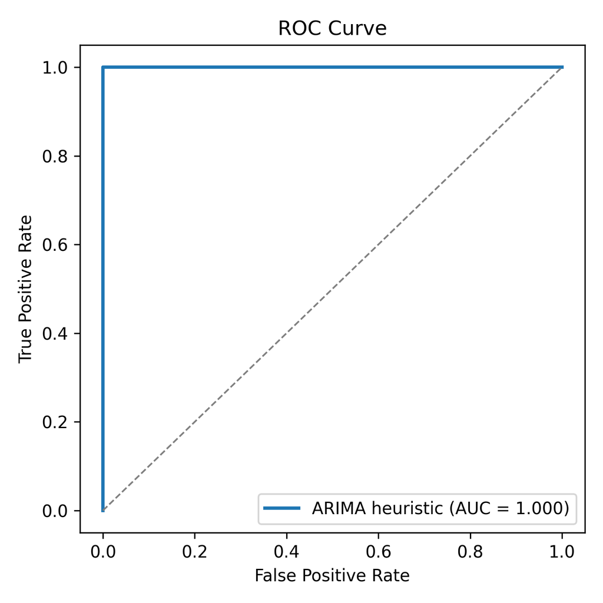

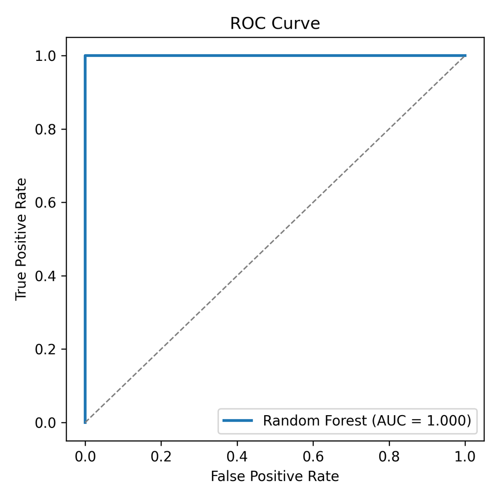

**(a) ARIMA ROC Curve**

**(b) Random Forest ROC Curve**

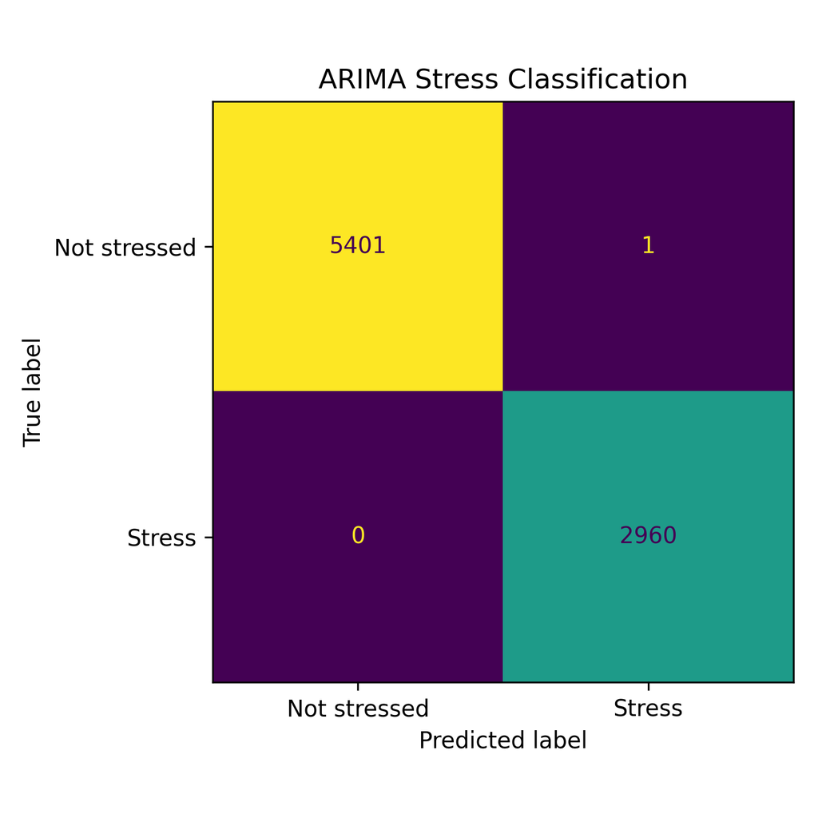

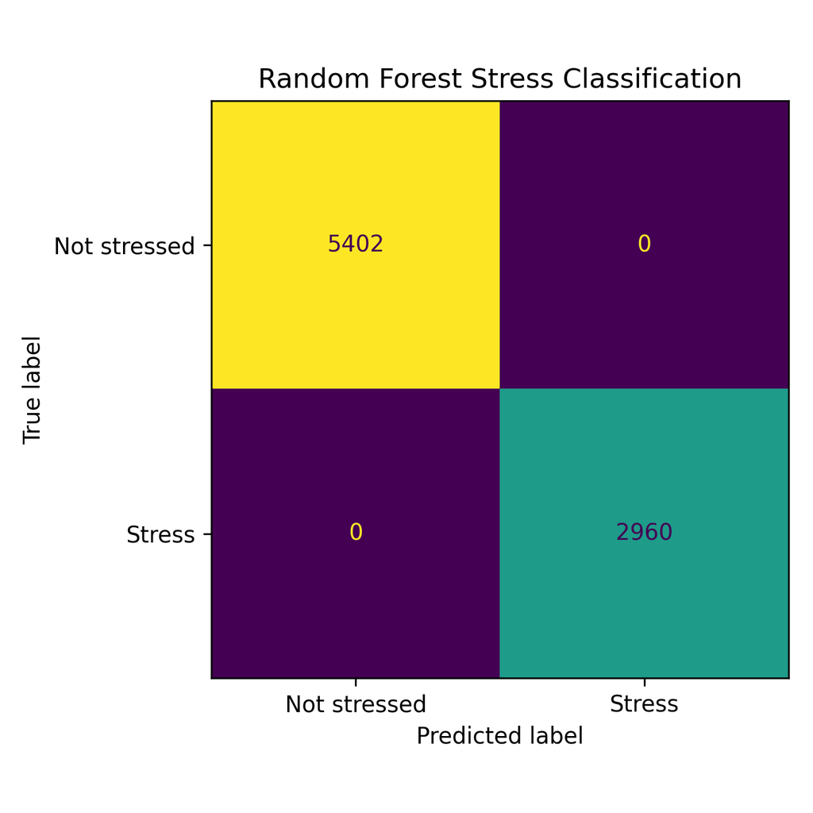

**(c) ARIMA Confusion Matrix**

**(d) Random Forest Confusion Matrix**

*Figure B. Comparison of ARIMA and Random Forest performance for EDA (Subject S4) using a 3-minute rolling window.*

In the case above, both models performed well, showing how metrics with a significant physiological difference between baseline and stress state allows for even a simple heuristic model based on nearest-mean classification can achieve accurate classification. This suggests that when there is a clear physiological difference when under stress, complex machine learning algorithms may provide only small improvements.

ARIMA

Random Forest

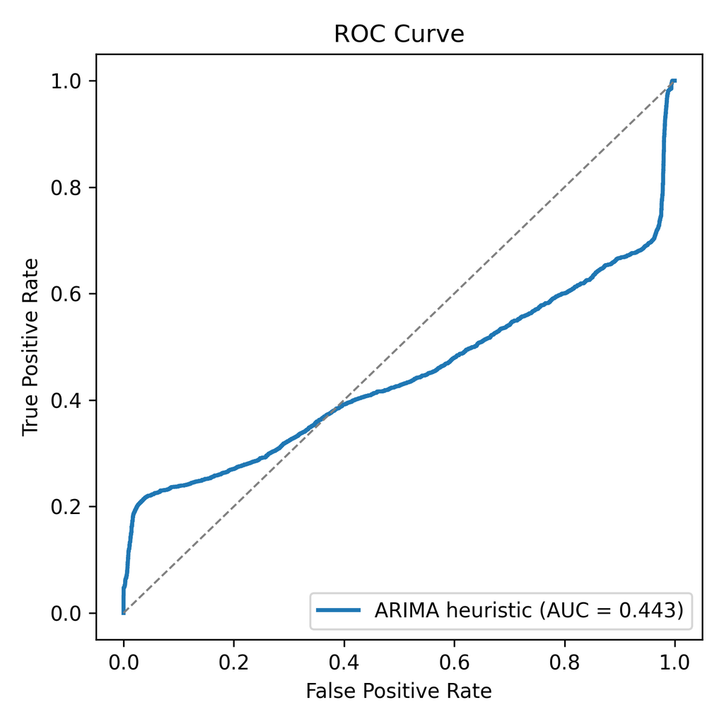

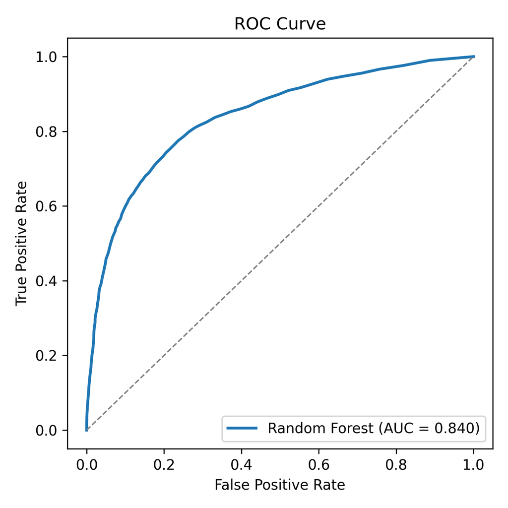

**(a) ARIMA ROC Curve**

**(b) Random Forest ROC Curve**

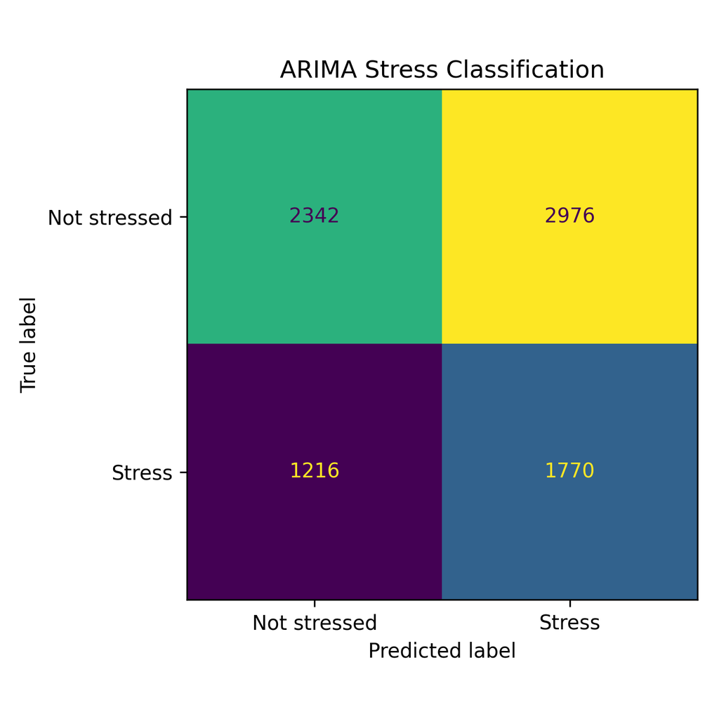

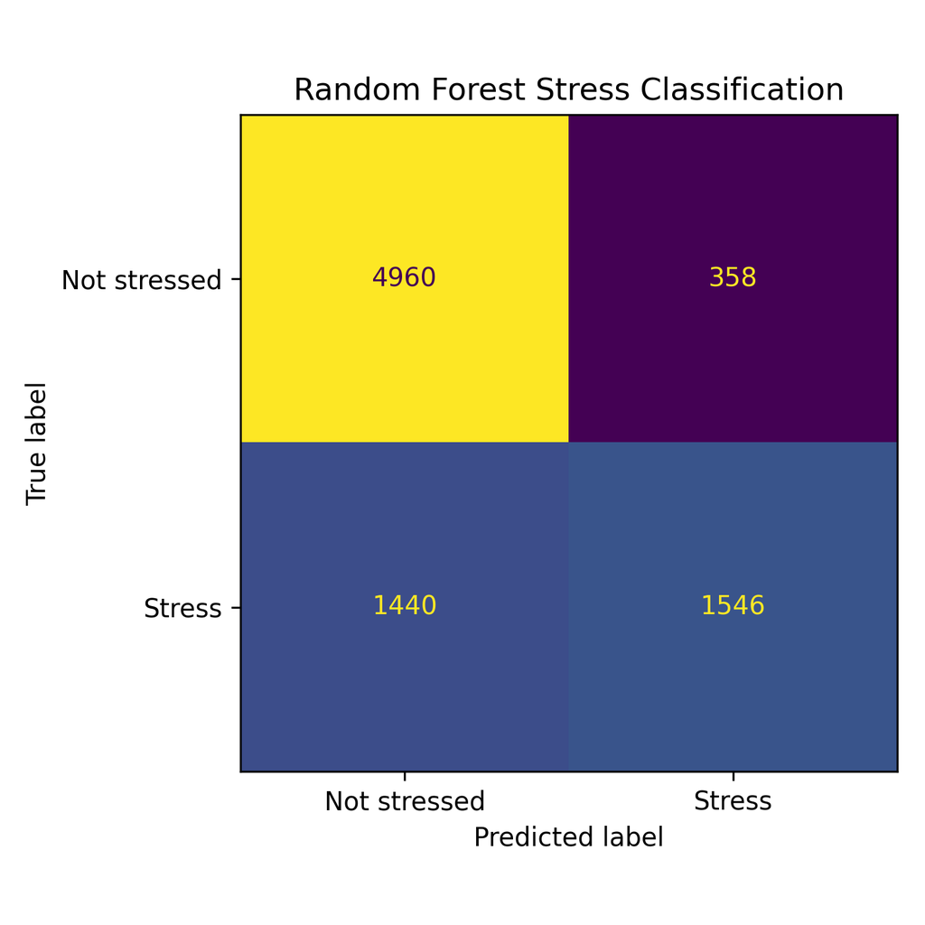

**(c) ARIMA Confusion Matrix**

**(d) Random Forest Confusion Matrix**

*Figure C. Comparison of ARIMA and Random Forest performance for RESP (Subject S3) using a 3-minute rolling window.*

In this case, RESP proved to be a more difficult classification problem. Although neither model had near-perfect classification, we see again how Random Forest has a greater ability to capture patterns related to stress and provided better results than the ARIMA-based approach. This difference in performance was consistently shown when there was a less obvious physiological difference in stress state, limiting the effectiveness of mean-based classification.

ARIMA

Random Forest

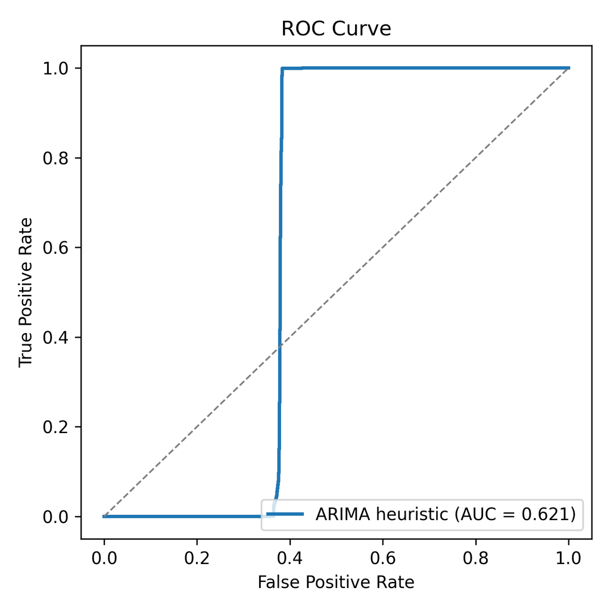

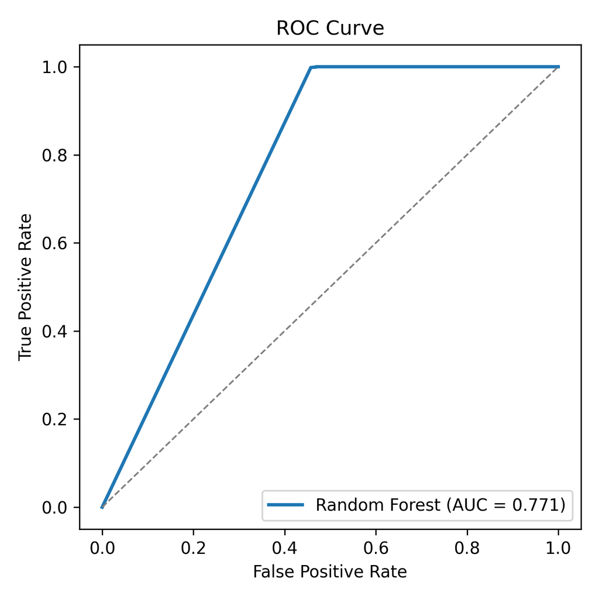

**(a) ARIMA ROC Curve**

**(b) Random Forest ROC Curve**

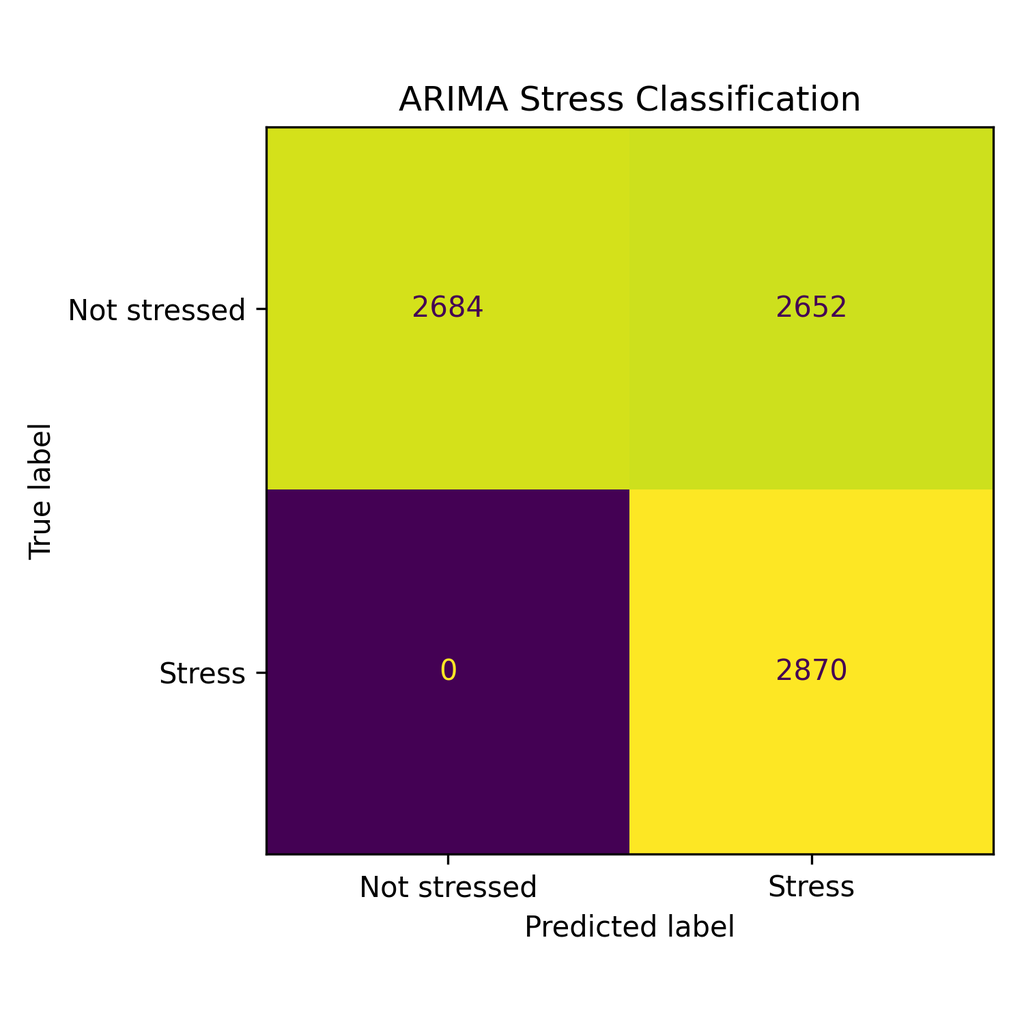

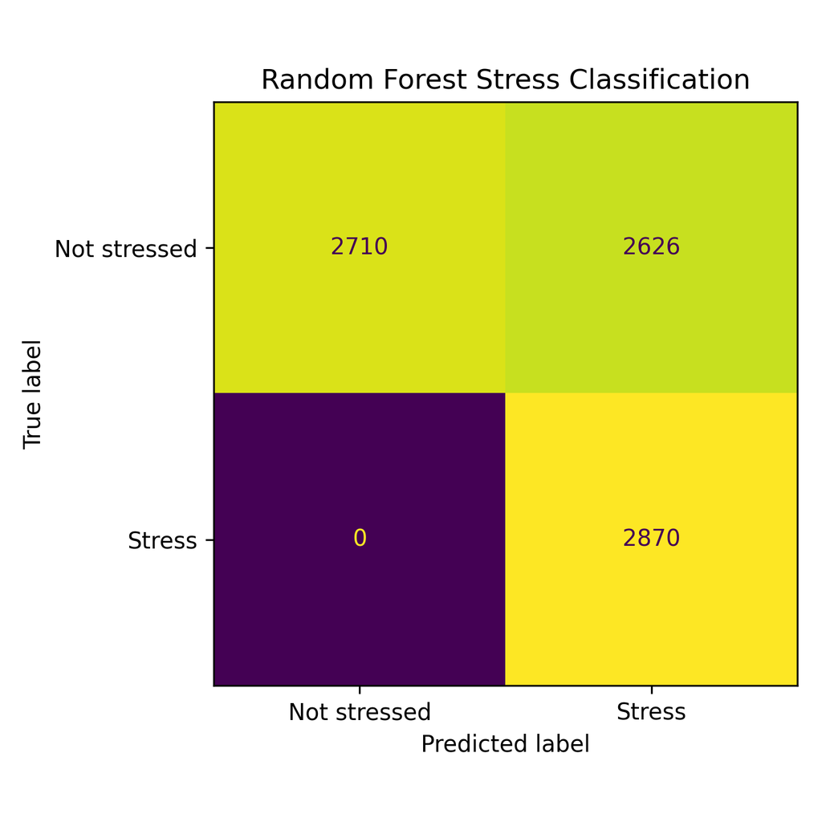

**(c) ARIMA Confusion Matrix**

**(d) Random Forest Confusion Matrix**

*Figure D. Comparison of ARIMA and Random Forest performance for TEMP (Subject S2) using a 3-minute rolling window.*

## Conclusion

**Results:** This paper performed a comparative analysis of two classifiers in two different data window sizes (1-minute, 3-minute) for all three subjects (S2–S4) of stress states derived from chest sensor data (ECG, EDA, TEMP, RESP) using ARIMA and Random Forest classifiers. Random Forest consistently outperformed ARIMA overall — mean accuracy was 0.76 vs. 0.53 (1-min) and 0.78 vs. 0.54 (3-min), with an even wider F1 gap (0.74 vs. 0.31 and 0.76 vs. 0.43). There was a wide range of this gap across signals. However, ARIMA fared poorly in the ECG and RESP datasets, and its ROC curves yielded AUC near or below 0.5 (random), indicating that the ARIMA-based nearest-mean classification is not valid for these signals when capturing their stress-sensitive behavior. The only time that ARIMA outperformed Random Forest was during the 3-minute window for S2 (Random Forest F1 was 0.6799, while ARIMA’s was 0.6840). The most erratic signal was EDA, a signal that went from near-perfect (S4) to near-zero (S2), indicating that subject-specific signal characteristics likely had substantial influence on classification performance. Increasing the window size from 1 minute to 3 minutes showed limited improvement in both model, but helped ARIMA-based classification, with an average F1 improved on the order of 13 points with the larger 3 minute window. This corroborates the findings of ARIMA’s improved ECG forecasting accuracy at longer windows, which in turn helps nearest-mean classification.

## References

Aigrain, Jonathan, Séverine Dubuisson, Marcin Detyniecki, and Mohamed Chetouani. 2015. “Person-Specific Behavioural Features for Automatic Stress Detection.” *2015 11th IEEE International Conference and Workshops on Automatic Face and Gesture Recognition*, 1–6. https://doi.org/10.1109/FG.2015.7284844.

Beltran, Roxanne S. 2024. “Overcoming the Pitfalls of Categorizing Continuous Variables in Ecology, Evolution and Behaviour.” *Proceedings of the Royal Society B* 291 (2032): 20241640. https://doi.org/10.1098/rspb.2024.1640.

Garg, Pooja, Jayasankar Santhosh, Andreas Dengel, and Shoya Ishimaru. 2021. “Stress Detection by Machine Learning and Wearable Sensors.” *IUI ’21 Companion*, ahead of print. https://doi.org/10.1145/3397482.3450732.

Kontopoulou, Vaia I., Athanasios D. Panagopoulos, Ioannis Kakkos, and George K. Matsopoulos. 2023. “A Review of ARIMA Vs. Machine Learning Approaches for Time Series Forecasting in Data Driven Networks.” *Future Internet* 15 (8): 255. https://doi.org/10.3390/fi15080255.

Luzzani, Irene Buraioli, Giorgio, and Danilo Demarchi. 2024. “EDA, PPG and Skin Temperature as Predictive Signals for Mental Failure by a Statistical Analysis on Stress and Mental Workload.” *IEEE Open Journal of Engineering in Medicine and Biology* 6: 1–9. https://doi.org/10.1109/OJEMB.2024.3515473.

Oyeleye, Matthew, Tao Chen, Sofya Titarenko, and Georgios Antoniou. 2022. “A Predictive Analysis of Heart Rates Using Machine Learning Techniques.” *International Journal of Environmental Research and Public Health* 19 (4): 2417. https://doi.org/10.3390/ijerph19042417.

Schmidt, Philip, and Attila Reiss. 2018. “WESAD: A Multimodal Dataset for Wearable Stress and Affect Detection.” *Proceedings of the 20th ACM International Conference on Multimodal Interaction*. https://doi.org/10.1145/3242969.3242985.

Sosa, Adam K. Fontecchio, Santiago, and Jennifer S. Atchison. 2026. “Beyond EDA: A Systematic Review of Multimodal Sympathetic Nervous System Arousal Classification for Stress Detection.” *Sensors* 26 (5): 1584. https://doi.org/10.3390/s26051584.

Ziyadidegan, Sanaz, Nasim Sadeghi, Mohammadreza Razavi, et al. 2025. “Quantifying Mental Stress Using Cardiovascular Responses: A Scoping Review.” *PMC*.